# Tugas Praktikum 7

# Packages

```r
library(ggplot2)
library(tsibble)
library(tseries)
library(MASS)
library(forecast)
library(TSA)
library(TTR)
library(aTSA)
library(graphics)
```

# Data

Data yang digunakan adalah data pembagian dari tugas kelompok. Data tersebut merupakan data jumlah penumpang Transjakarta harian tahun 2023-2024. Data tersebut berupa data deret waktu yang terdiri dari 109 periode.

```r
dt <- read.csv("D:\\IPB\\Statistika Sem 5\\MPDW (Deret Waktu)\\Data Jumlah Penumpang Transjakarta Harian Tahun 2023-2024.csv", sep =";")
dt <- dt[219:327,2]
dt
```

```
##   [1] 1006666 1011406 1000208  991508  982905  676818  597413 1008471 1011261
##  [10]  989925  535537  941749  625534  498446  433517  418970  416837  409463
##  [19]  408345  282422  246739  420126  422024  430748  417971 1015361  695963
##  [28]  617558 1026591 1014345 1014851 1007231 1032009  700670  621726 1065550
##  [37] 1078830 1074826 1070391 1064895  711037  605562 1080611 1094329 1101370
##  [46] 1090495 1081846  742942  611442 1100966 1105993 1109120  615710 1043002
##  [55]  730363  650239 1083284 1105891 1100992 1102279 1087623  725319  630556
##  [64] 1100382 1109216 1107503 1103250 1093067  727497  635855 1107316 1128713
##  [73] 1121625 1110376 1097821  721052  629687 1104758 1120393 1107625 1111359
##  [82] 1097914  748153  633768 1109764 1121596 1117922 1121811 1101969  735079
##  [91]  642921 1121028 1130181 1128956 1124007 1101730  748574  653803 1135364
## [100] 1146542 1132691 1131441 1126115  744568  654569 1146384 1149804 1171288
## [109] 1145343
```

# Eksplorasi Data

## Plot Data Penuh

Sebelum masuk dalam tahap pemodelan, dilakukan eksplorasi data dengan plot deret waktu untuk melihat pola data.

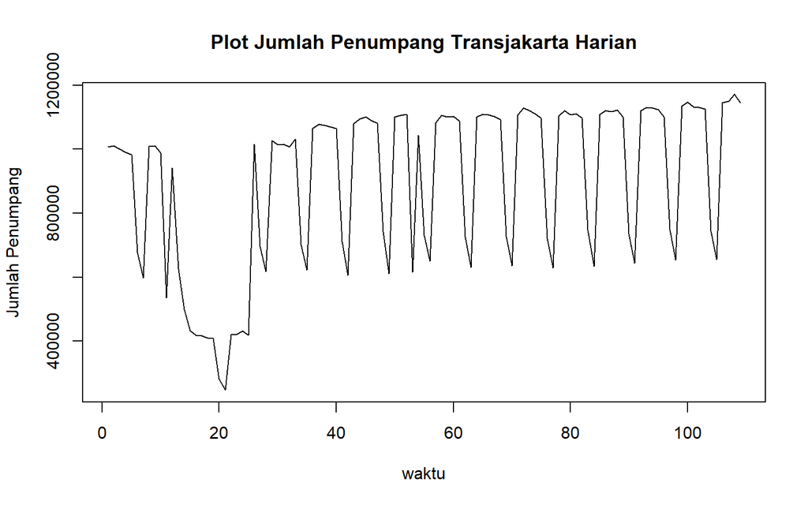

```r
plot.ts(dt, lty=1, xlab="waktu", ylab="Jumlah Penumpang", main="Plot Jumlah Penumpang Transjakarta Harian")
```

Berdasarkan plot data deret waktu di atas, terlihat data membentuk pola *seasonal* dan cenderung bergerak menyebar di sekitar nilai tengahnya 8e+05 sehingga bisa disimpulkan data tersebut stasioner dalam rataan. Selanjutnya, kita akan membagi datanya menjadi data latih dan data uji. Berdasarkan pola data, pembagian data latih dan data uji ditetapkan dengan proporsi 80%:20%.

## Plot Data Latih

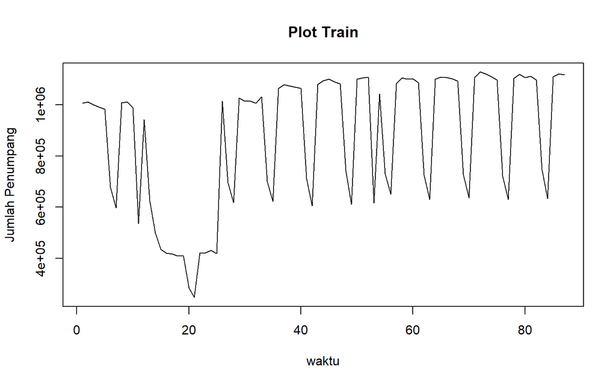

```r
train.ts <- ts(dt[1:87])
plot.ts(train.ts, lty=1, xlab="waktu", ylab="Jumlah Penumpang", main="Plot Train")
```

Berdasarkan plot data deret waktu pada data latih di atas, terlihat data membentuk pola *seasonal* dan cenderung bergerak menyebar di sekitar nilai tengahnya 8e+05 sehingga bisa disimpulkan data tersebut stasioner dalam rataan.

## Plot Data Uji

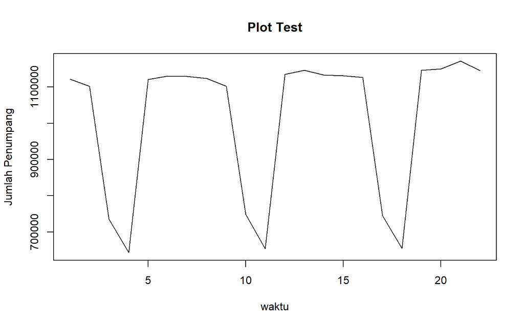

```r
test.ts <- ts(dt[88:109])
plot.ts(test.ts, lty=1, xlab="waktu", ylab="Jumlah Penumpang", main="Plot Test")
```

# Uji Stasioneritas Data

Selain dengan plot data deret waktu, akan dilakukan pengecekan stasioneritas data dengan plot ACF dan uji ADF.

## Plot ACF

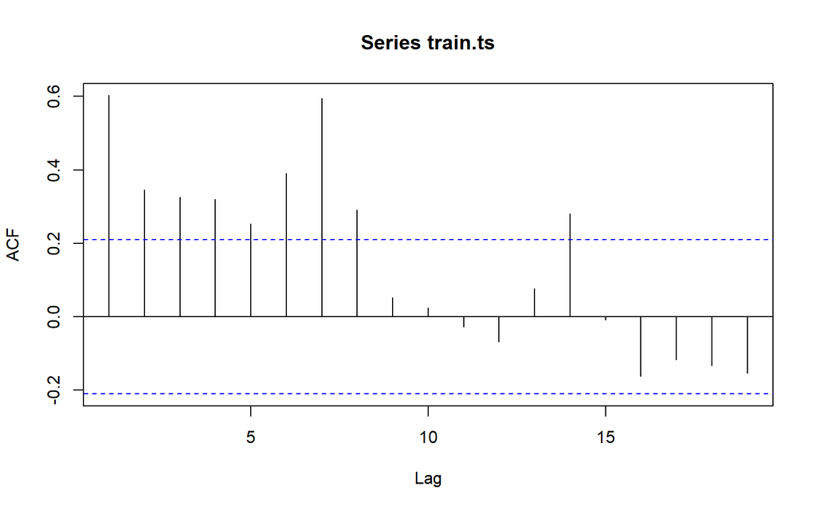

```r
acf(train.ts)
```

Berdasarkan plot ACF di atas, cenderung membentuk pola *cuts off* pada lag 8 sehingga menandakan data stasioner dalam rataan. Selain dengan plot ACF, akan dilakukan uji ADF untuk mengecek stasioneritas data.

## Uji ADF

```r
tseries::adf.test(train.ts)
```

```
##
##  Augmented Dickey-Fuller Test
##
## data:  train.ts
## Dickey-Fuller = -3.5353, Lag order = 4, p-value = 0.04375
## alternative hypothesis: stationary
```

$H_0$ : Data tidak stasioner dalam rataan

$H_1$ : Data stasioner dalam rataan

Berdasarkan uji ADF tersebut, didapat *p-value* sebesar 0.04375 yang lebih kecil dari taraf nyata 5% sehingga tolak $H_0$ dan menandakan bahwa data stasioner dalam rataan. Hal ini sesuai dengan hasil eksplorasi menggunakan plot time series dan plot ACF, dan plot ADF.

## Plot Box-Cox

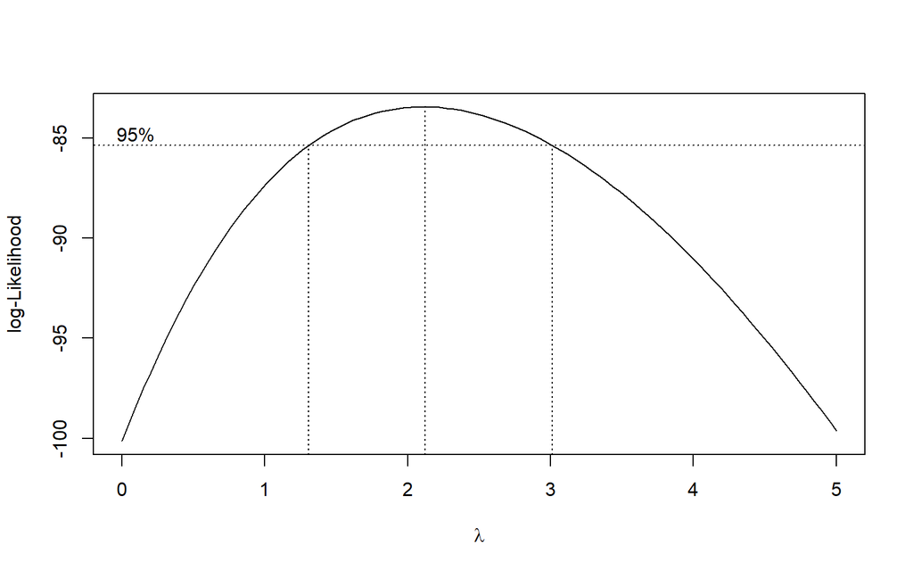

```r
index <- seq(1:87)
bc = boxcox(train.ts~index, lambda = seq(0,5,by=1))
```

```r
#Nilai Rounded Lambda
lambda <- bc$x[which.max(bc$y)]
lambda
```

```
## [1] 2.121212
```

```r
#SK
bc$x[bc$y > max(bc$y) - 1/2 * qchisq(.95,1)]
```

```
##  [1] 1.313131 1.363636 1.414141 1.464646 1.515152 1.565657 1.616162 1.666667
##  [9] 1.717172 1.767677 1.818182 1.868687 1.919192 1.969697 2.020202 2.070707
## [17] 2.121212 2.171717 2.222222 2.272727 2.323232 2.373737 2.424242 2.474747
## [25] 2.525253 2.575758 2.626263 2.676768 2.727273 2.777778 2.828283 2.878788
## [33] 2.929293 2.979798
```

Plot Boxcox menunjukkan nilai *rounded value* ($\lambda$) optimum sebesar **2.12** dan pada selang kepercayaan 95% nilai memiliki batas bawah **1.31** dan batas atas **2.97**. Selang tersebut tidak memuat nilai satu sehingga dapat dikatakan bahwa data tidak stasioner dalam ragam.

# Penanganan Ketidakstasioneran Data

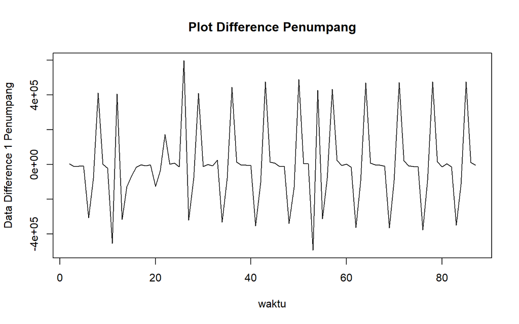

```r
train.diff<-diff(train.ts,differences = 1)
plot.ts(train.diff, lty=1, xlab="waktu", ylab="Data Difference 1 Penumpang", main="Plot Difference Penumpang")
```

Kita mencoba untuk mengatasi ketidakstasioneran pada ragam dengan melakukan differencing sekali. Berdasarkan plot data deret waktu, terlihat bahwa data masih stasioner dalam rataan ditandai dengan data bergerak pada nilai tengah tertentu, tetapi masih terlihat pola musiman. Selanjutnya, akan dilakukan uji ADF untuk mengecek stasioneritas data.

## Plot ACF

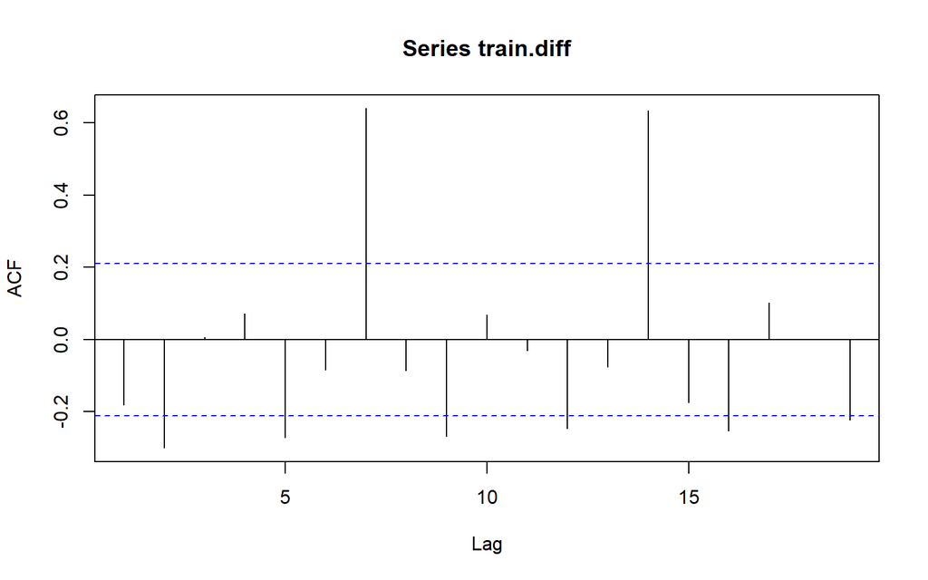

```r
acf(train.diff)
```

Berdasarkan plot tersebut, terlihat bahwa plot ACF cuts off pada lag ke 2. Hal ini menandakan data masih stasioner dalam rataan, namun masih terlihat adanya pola musiman.

## Uji ADF

```r
tseries::adf.test(train.diff)
```

```
##
##  Augmented Dickey-Fuller Test
##
## data:  train.diff
## Dickey-Fuller = -7.6098, Lag order = 4, p-value = 0.01
## alternative hypothesis: stationary
```

$H_0$ : Data tidak stasioner dalam rataan

$H_1$ : Data stasioner dalam rataan

Berdasarkan uji ADF tersebut, didapat *p-value* sebesar 0.01 yang lebih kecil dari taraf nyata 5% sehingga tolak $H_0$ atau data masih stasioner dalam rataan. Hal ini sesuai dengan hasil eksplorasi menggunakan plot time series dan plot ACF. Selanjutnya, kita akan melakukan identifikasi model

# Identifikasi Model

## Plot ACF

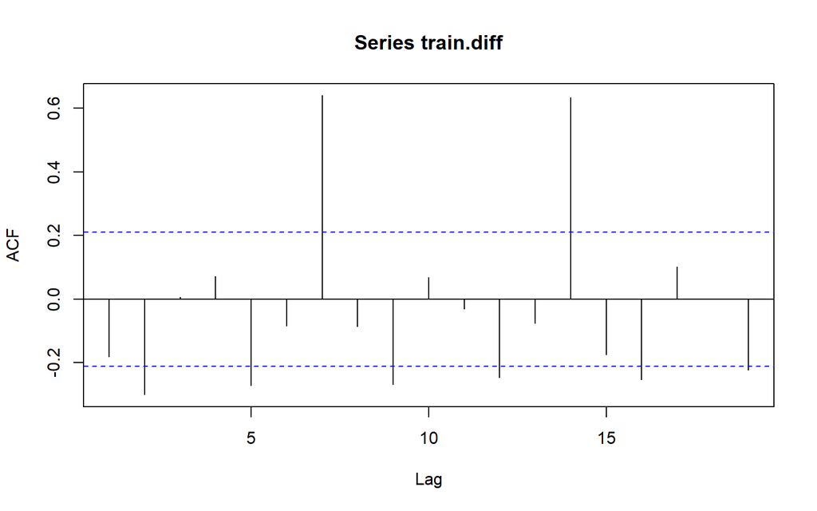

```r
acf(train.diff)
```

Berdasarkan plot tersebut, terlihat bahwa plot ACF cenderung *cuts off* pada lag ke 2, sehingga jika plot PACF dianggap *tails off*, maka model tentatifnya adalah ARIMA(0,1,2).

## Plot PACF

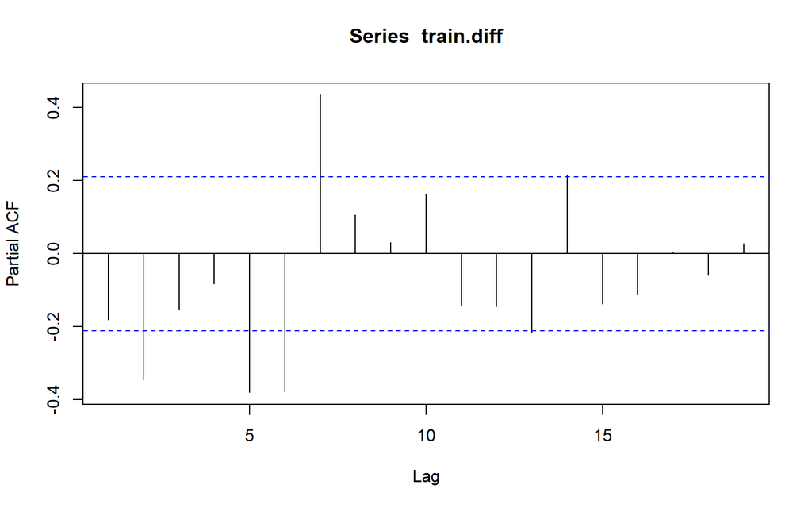

```r
pacf(train.diff)
```

Berdasarkan plot tersebut, terlihat bahwa plot PACF cenderung *tails off*, maka karena plot ACF dianggap *cuts off* pada lag 2, maka model tentatifnya adalah ARIMA(0,1,2).

## Plot EACF

```r
eacf(train.diff)
```

```
## AR/MA
##   0 1 2 3 4 5 6 7 8 9 10 11 12 13
## 0 o x o o x o x o x o o  x  o  x
## 1 x x o o x o x o x o o  o  o  x
## 2 x o o o o o x o x o o  o  o  x
## 3 x o x o o o x o o o o  o  o  x
## 4 o x x o o o x o o o o  o  o  x
## 5 x x x o o x x x o o o  o  x  x
## 6 x x x x x o o o o o x  o  x  o
## 7 x o o x o o o o o o o  o  o  o
```

```r
#terdapat 5 model tentatif
#ARIMA(0,1,2), ARIMA(1,1,2), ARIMA(2,1,2), ARIMA(2,1,3) dan ARIMA(3,1,3)
```

Identifikasi model menggunakan plot EACF dilakukan dengan melihat ujung segitiga pada pola segitiga nol. Dalam hal ini model tentatif yang terbentuk adalah ARIMA(0,1,2), ARIMA(1,1,2), ARIMA(2,1,2), ARIMA(2,1,3) dan ARIMA(3,1,3).

# Pendugaan Parameter Model Tentatif

## ARIMA(0,1,2)

```r
model1.da=Arima(train.diff, order=c(0,0,2),method="ML")
summary(model1.da) #AIC=2357.46
```

```
## Series: train.diff
## ARIMA(0,0,2) with non-zero mean
##
## Coefficients:
##           ma1      ma2      mean
##       -0.3695  -0.3379  1278.564
## s.e.   0.1018   0.1019  6815.735
##
## sigma^2 = 4.41e+10:  log likelihood = -1174.73
## AIC=2357.46   AICc=2357.95   BIC=2367.28
##
## Training set error measures:
##                     ME     RMSE      MAE      MPE     MAPE      MASE
## Training set -2807.839 206310.8 165382.9 593.7479 1273.469 0.6352072
##                      ACF1
## Training set -0.006162581
```

```r
lmtest::coeftest(model1.da) #seluruh parameter signifikan
```

```
##
## z test of coefficients:
##
##             Estimate Std. Error z value  Pr(>|z|)
## ma1         -0.36947    0.10184 -3.6279 0.0002858 ***
## ma2         -0.33791    0.10189 -3.3163 0.0009120 ***
## intercept 1278.56397 6815.73518  0.1876 0.8511980
## ---
## Signif. codes:  0 '***' 0.001 '**' 0.01 '*' 0.05 '.' 0.1 ' ' 1
```

## ARIMA(1,1,2)

```r
model2.da=Arima(train.diff, order=c(1,0,2),method="ML")
summary(model2.da) #AIC=2359.46
```

```
## Series: train.diff
## ARIMA(1,0,2) with non-zero mean
##
## Coefficients:
##           ar1      ma1      ma2      mean
##       -0.0186  -0.3531  -0.3457  1259.289
## s.e.   0.3014   0.2830   0.1712  6884.119
##
## sigma^2 = 4.464e+10:  log likelihood = -1174.73
## AIC=2359.46   AICc=2360.21   BIC=2371.73
##
## Training set error measures:
##                     ME     RMSE      MAE      MPE     MAPE      MASE
## Training set -2724.168 206309.9 165541.3 593.5997 1274.969 0.6358155
##                      ACF1
## Training set -0.004279215
```

```r
lmtest::coeftest(model2.da) #hanya ma2 yang signifikan
```

```
##
## z test of coefficients:
##
##              Estimate  Std. Error z value Pr(>|z|)
## ar1         -0.018594    0.301388 -0.0617  0.95080
## ma1         -0.353102    0.282980 -1.2478  0.21211
## ma2         -0.345750    0.171201 -2.0195  0.04343 *
## intercept 1259.288515 6884.119283  0.1829  0.85486
## ---
## Signif. codes:  0 '***' 0.001 '**' 0.01 '*' 0.05 '.' 0.1 ' ' 1
```

## ARIMA(2,1,2)

```r
model3.da=Arima(train.diff, order=c(2,0,2),method="ML")
summary(model3.da) #AIC=2360.95
```

```
## Series: train.diff
## ARIMA(2,0,2) with non-zero mean
##
## Coefficients:
##          ar1      ar2      ma1      ma2       mean
##       0.2345  -0.1927  -0.6082  -0.0839   918.5542
## s.e.  0.5491   0.2686   0.5606   0.4752  7379.3470
##
## sigma^2 = 4.492e+10:  log likelihood = -1174.47
## AIC=2360.95   AICc=2362.01   BIC=2375.67
##
## Training set error measures:
##                     ME     RMSE      MAE      MPE     MAPE      MASE
## Training set -1793.515 205683.5 165225.7 573.5498 1316.727 0.6346032
##                      ACF1
## Training set -0.004530028
```

```r
lmtest::coeftest(model3.da) #tidak ada yang signifikan
```

```
##
## z test of coefficients:
##
##              Estimate  Std. Error z value Pr(>|z|)
## ar1          0.234487    0.549100  0.4270   0.6694
## ar2         -0.192709    0.268593 -0.7175   0.4731
## ma1         -0.608169    0.560596 -1.0849   0.2780
## ma2         -0.083948    0.475230 -0.1766   0.8598
## intercept  918.554207 7379.346967  0.1245   0.9009
```

## ARIMA(2,1,3)

```r
model4.da=Arima(train.diff, order=c(2,0,3),method="ML")
summary(model4.da) #AIC=2346.48
```

```
## Series: train.diff
## ARIMA(2,0,3) with non-zero mean
##
## Coefficients:
##           ar1      ar2     ma1     ma2      ma3       mean
##       -0.4676  -0.9886  0.2663  0.8276  -0.3027   2351.516
## s.e.   0.0167   0.0179  0.1661  0.1293   0.1944  14323.629
##
## sigma^2 = 3.522e+10:  log likelihood = -1166.24
## AIC=2346.48   AICc=2347.91   BIC=2363.66
##
## Training set error measures:
##                     ME     RMSE    MAE      MPE     MAPE      MASE       ACF1
## Training set -367.2812 181015.5 145414 416.2196 1361.842 0.5585098 0.03492738
```

```r
lmtest::coeftest(model4.da) #ma1 dan ma3 tidak signifikan
```

```
##
## z test of coefficients:
##
##              Estimate  Std. Error  z value  Pr(>|z|)
## ar1       -4.6762e-01  1.6738e-02 -27.9378 < 2.2e-16 ***
## ar2       -9.8864e-01  1.7949e-02 -55.0796 < 2.2e-16 ***
## ma1        2.6629e-01  1.6612e-01   1.6030    0.1089
## ma2        8.2765e-01  1.2929e-01   6.4017 1.536e-10 ***
## ma3       -3.0273e-01  1.9436e-01  -1.5576    0.1193
## intercept  2.3515e+03  1.4324e+04   0.1642    0.8696
## ---
## Signif. codes:  0 '***' 0.001 '**' 0.01 '*' 0.05 '.' 0.1 ' ' 1
```

## ARIMA(3,1,3)

```r
model5.da=Arima(train.diff, order=c(3,0,3),method="ML")
summary(model5.da) #AIC=2339.33
```

```
## Series: train.diff
## ARIMA(3,0,3) with non-zero mean
##
## Coefficients:
##          ar1      ar2     ar3      ma1     ma2      ma3      mean
##       0.2032  -0.6922  0.6642  -0.5094  0.5096  -0.9998  4176.261
## s.e.  0.1027   0.0406  0.0943   0.1400  0.1421   0.0646  2039.452
##
## sigma^2 = 3.098e+10:  log likelihood = -1161.66
## AIC=2339.33   AICc=2341.2   BIC=2358.96
##
## Training set error measures:
##                     ME     RMSE      MAE      MPE     MAPE     MASE        ACF1
## Training set -12702.76 168693.6 136894.2 565.7126 1496.707 0.525787 -0.01547824
```

```r
lmtest::coeftest(model5.da) #seluruh parameter signifikan
```

```
##
## z test of coefficients:
##
##              Estimate  Std. Error  z value  Pr(>|z|)
## ar1          0.203164    0.102680   1.9786 0.0478594 *
## ar2         -0.692229    0.040579 -17.0590 < 2.2e-16 ***
## ar3          0.664210    0.094338   7.0407 1.912e-12 ***
## ma1         -0.509376    0.140036  -3.6375 0.0002753 ***
## ma2          0.509562    0.142057   3.5870 0.0003345 ***
## ma3         -0.999833    0.064634 -15.4692 < 2.2e-16 ***
## intercept 4176.261186 2039.451953   2.0477 0.0405858 *
## ---
## Signif. codes:  0 '***' 0.001 '**' 0.01 '*' 0.05 '.' 0.1 ' ' 1
```

## Kesimpulan

Berdasarkan pendugaan parameter di atas, nilai AIC terkecil dimiliki oleh model ARIMA(3,1,3) dan parameter model ARIMA(3,1,3) juga seluruhnya signifikan sehingga model yang dipilih adalah model ARIMA(3,1,3).

# Analisis Sisaan

Model terbaik hasil identifikasi kemudian dicek asumsi sisaannya. Sisaan model ARIMA harus memenuhi asumsi normalitas, kebebasan sisaan, dan kehomogenan ragam. Diagnostik model dilakukan secara eksplorasi dan uji formal.

## Eksplorasi Sisaan

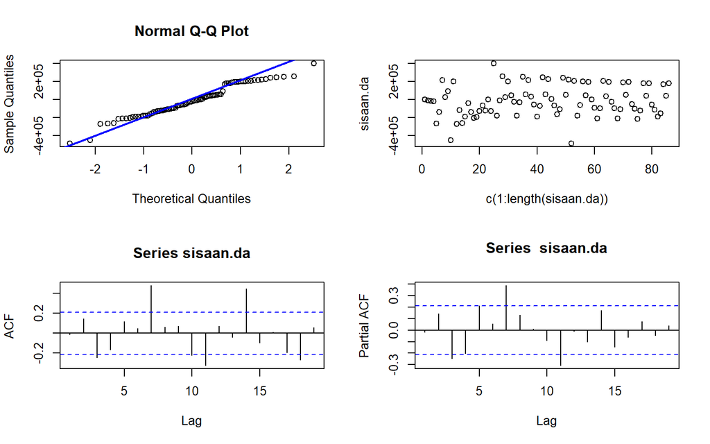

```r
#Eksplorasi
sisaan.da <- model5.da$residuals
par(mfrow=c(2,2))
qqnorm(sisaan.da)
qqline(sisaan.da, col = "blue", lwd = 2)
plot(c(1:length(sisaan.da)),sisaan.da)
acf(sisaan.da)
pacf(sisaan.da)
```

```r
par(mfrow = c(1,1))
```

## Uji Formal

### Sisaan Menyebar Normal

```r
#1) Sisaan Menyebar Normal
ks.test(sisaan.da,"pnorm")  #tak tolak H0 > sisaan menyebar normal
```

```
##
##  Exact one-sample Kolmogorov-Smirnov test
##
## data:  sisaan.da
## D = 0.56977, p-value = 3.331e-16
## alternative hypothesis: two-sided
```

Selain dengan eksplorasi, asumsi tersebut dapat diuji menggunakan uji formal. Pada tahapan ini uji formal yang digunakan untuk normalitas adalah uji Kolmogorov-Smirnov (KS). Hipotesis pada uji KS adalah sebagai berikut.

$H_0$ : Sisaan menyebar normal

$H_1$ : Sisaan tidak menyebar normal

Berdasarkan uji KS tersebut, didapat *p-value* sebesar 3.331e-16 yang kurang dari taraf nyata 5% sehingga tolak $H_0$ dan menandakan bahwa sisaan tidak menyebar normal. Hal ini sesuai dengan hasil eksplorasi menggunakan plot kuantil-kuantil normal.

### Sisaan Saling Bebas

```r
#2) Sisaan saling bebas/tidak ada autokorelasi
Box.test(sisaan.da, type = "Ljung")  #tak tolak H0 > sisaan saling bebas
```

```
##
##  Box-Ljung test
##
## data:  sisaan.da
## X-squared = 0.021331, df = 1, p-value = 0.8839
```

Selanjutnya akan dilakukan uji formal untuk kebebasan sisaan menggunakan uji Ljung-Box. Hipotesis yang digunakan adalah sebagai berikut.

$H_0$ : Sisaan saling bebas

$H_1$ : Sisaan tidak tidak saling bebas

Berdasarkan uji Ljung-Box tersebut, didapat *p-value* sebesar 0.8839 yang lebih besar dari taraf nyata 5% sehingga tak tolak $H_0$ dan menandakan bahwa sisaan saling bebas. Hal ini berbeda dengan eksplorasi.

### Sisaan Homogen

```r
#3) Sisaan homogen
Box.test((sisaan.da)^2, type = "Ljung")  #tak tolak H0 > sisaan homogen
```

```
##
##  Box-Ljung test
##
## data:  (sisaan.da)^2
## X-squared = 0.18751, df = 1, p-value = 0.665
```

Hipotesis yang digunakan untuk uji kehomogenan ragam adalah sebagai berikut.

$H_0$ : Ragam sisaan homogen

$H_1$ : Ragam sisaan tidak homogen

Berdasarkan uji Ljung-Box terhadap sisaan kuadrat tersebut, didapat *p-value* sebesar 0.665 yang lebih besar dari taraf nyata 5% sehingga tak tolak $H_0$ dan menandakan bahwa ragam sisaan homogen.

### Nilai Tengah Sisaan sama dengan Nol

```r
#4) Nilai tengah sisaan sama dengan nol
t.test(sisaan.da, mu = 0, conf.level = 0.95)  #tak tolak h0 > nilai tengah sisaan sama dengan 0
```

```
##
##  One Sample t-test
##
## data:  sisaan.da
## t = -0.69622, df = 85, p-value = 0.4882
## alternative hypothesis: true mean is not equal to 0
## 95 percent confidence interval:
##  -48979.57  23574.06
## sample estimates:
## mean of x
## -12702.76
```

Terakhir, dengan uji-t, akan dicek apakah nilai tengah sisaan sama dengan nol. Hipotesis yang diujikan sebagai berikut.

$H_0$ : nilai tengah sisaan sama dengan 0

$H_1$ : nilai tengah sisaan tidak sama dengan 0

Berdasarkan uji-ttersebut, didapat *p-value* sebesar 0.4882 yang lebih besar dari taraf nyata 5% sehingga tak tolak $H_0$ dan menandakan bahwa nilai tengah sisaan sama dengan nol. Hal ini berbeda dengan eksplorasi.